# Wartime sexual violence and intergroup trust

Analyzing causal effect modification in conjoint experiment.

- Forced-choice conjoint experiments designed to measure interpersonal trust (would you rather give phone to person A or person B)
- Treatment: person ethnic ingroup vs. ethnic outgroup
- Effect modifier: wartime sexual violence (self or family member)

So RQ:

> Does direct or indirect exposure to wartime sexual violence affect intergroup trust (= change how ethnic group membership affects trust)?

# Setup

```r
library(dplyr)
library(ggplot2)
library(lmtest)
library(marginaleffects)
library(purrr)
library(sandwich)
library(survey)
library(tidyr)

# for plots:
library(showtext)
library(sysfonts)

font_add(
  "Gyre",
  regular = "/usr/share/texmf/fonts/opentype/public/tex-gyre/texgyretermes-regular.otf"
)

showtext_auto()

theme_paper <- function(base_size = 14, base_family = "Gyre") {
  theme_minimal(base_size = base_size, base_family = base_family) +
    theme(
      panel.grid.major = element_line(color = "#E5E5E5", linewidth = 0.4),
      panel.grid.minor = element_blank(),

      axis.line = element_line(color = "black"),
      axis.ticks = element_line(color = "black"),

      axis.text = element_text(color = "black"),
      axis.title = element_text(color = "black"),

      plot.title = element_text(face = "bold", size = rel(1.2)),
      plot.subtitle = element_text(color = "black"),

      legend.position = "right",
      legend.title = element_text(face = "bold"),

      panel.background = element_blank(),
      plot.background = element_blank()
    )
}

theme_set(theme_paper())


set.seed(42)
```

# Data

```r
survey <- readr::read_csv(here::here("data/survey.csv"))
conjoint <- readr::read_csv(here::here("data/conjoint.csv"))
pscores_full <- readr::read_csv(here::here("data/propensity_scores.csv"))

sampling <- haven::read_dta(here::here("data/design_weights_shortID.dta"))
list_exp <- readr::read_csv(here::here("data/list_experiment.csv"))

# Select which propensity score estimates & weights to use:
pscores <- pscores_full |> filter(id == "XGBoost") |> select(-id)
```

# Prep

Joining everything together & merging with conjoint. Operationalizations:

- crsv: self-reported crsv (self or family member)
- Outgroup: profile belongs to a different ethnic group than respondent
- Trust: profile selected (e.g. would give phone to that person)

```r
survey <-
  survey |>
  # older than 12 at start of war:
  filter(resp_age > 43) |>
  fastDummies::dummy_cols(c("resp_ethn", "resp_educ")) |>
  left_join(pscores, join_by(uuid)) |>
  left_join(sampling, join_by(prc_id == shortID))

# Merge into conjoint experiments:

merged <-
  conjoint |>
  left_join(survey, join_by(uuid)) |>
  mutate(
    across(where(is.character), factor),
    outgroup = if_else(resp_ethn != ethnicity, 1, 0),
    # second outgroup measure: wartime enemies
    # (can play with the specification a little here. Since it's all
    # random it does not matter; only affects propensities but not
    # independence as long as common support & positivity hold)
    outgroup2 = if_else(
      (resp_ethn %in% c("Bosniak", "Croat") & ethnicity == "Serb") |
        (resp_ethn == "Serb" & ethnicity %in% c("Bosniak", "Croat")),
      1L,
      0L
    ),
    ingroup = 1 - outgroup,
    ingroup2 = 1 - outgroup2
  ) |>
  drop_na(resp_ethn) |>
  fastDummies::dummy_cols(
    c("ethnicity", "age", "class", "education", "sex", "resp_ethn"),
    remove_selected_columns = TRUE
  ) |>
  select(-c(scenario, round, profile, trust, choice))
```

# Descriptives

```r
w_wts <-
  sampling |>
  select(
    prc_id = shortID, stratum = highrisk,
    sampling_weight = w_resp_all_upscaled
  ) |>
  right_join(survey, join_by(prc_id)) |>
  drop_na(prc_id)
```

Survey designs weights etc.:

```r
design <- svydesign(
  ids = ~prc_id,
  weights = ~sampling_weight,
  strata = ~stratum,
  data = w_wts
)

unadjusted <- svydesign(ids = ~1, weights = ~1, data = survey)

svy_descr <- function(form) {

  name <- labels(terms(form))

  stats <- tibble(
    Name = name,
    Mean = svymean(form, design, na.rm = TRUE),
    SD = sqrt(svyvar(form, design, na.rm = TRUE)),
    Min = min(survey[[name]], na.rm = TRUE),
    Max = max(survey[[name]], na.rm = TRUE),
    Count = unwtd.count(form, design)
  )

  stats |> mutate(across(-Name, as.numeric))
}
```

Descriptives table:

```r
list(
  ~resp_age,
  ~resp_male,
  ~resp_ethn_Bosniak,
  ~resp_ethn_Croat,
  ~resp_ethn_Serb
) |>
  map(function(f) {

    name <- labels(terms(f))

    stats <- tibble(
      Name = name,
      Mean = svymean(f, unadjusted, na.rm = TRUE), # change to `design` for wts
      SD = sqrt(svyvar(f, unadjusted, na.rm = TRUE)),
      Min = min(w_wts[[name]], na.rm = TRUE),
      Max = max(w_wts[[name]], na.rm = TRUE),
      Count = unwtd.count(f, unadjusted)
    )

    stats |> mutate(across(-Name, as.numeric))
  }) |>
  bind_rows() |>
  mutate(
    across(where(is.numeric), \(x) round(x, 2)),
    Name = Name |> gsub("resp_(ethn_)?", "", x = _) |> stringr::str_to_title()
  ) |>
  knitr::kable(format = "latex")
```

## List experiment

crsv (weighted) population estimates:

```r
svyciprop(~crsv_self, design = design, method = "logit")
```

```
                     2.5%   97.5%
crsv_self 0.01611 0.00713 0.03598
```

```r
svyciprop(~crsv_self_family, design = design, method = "logit")
```

```
                          2.5%  97.5%
crsv_self_family 0.0993 0.0598 0.1603
```

Sample estimates (to compare to list experiment):

```r
unadj_self <- svyciprop(~crsv_self, design = unadjusted, method = "logit")
unadj_family <- svyciprop(~crsv_self_family, design = unadjusted, method = "logit")

self_reported <-
  list(Self = unadj_self, Family = unadj_family) |>
  imap(function(prop, name) {
    tibble(
      name = name,
      lower = as.numeric(attr(prop, "ci")[1]),
      upper = as.numeric(attr(prop, "ci")[2]),
      estimate = as.numeric(prop)
    )
  }) |>
  bind_rows() |>
  mutate(across(-name, \(x) x * 100), type = "Self-reported")
```

Prevalence estimate from list experiment:

```r
list_exp <-
  list_exp |>
  drop_na(prc_id) |>
  mutate(
    across(
      contains("count"),
      \(x) x*100,
      .names = "{gsub('count', 'score', col)}"
    ),
    prc_id = factor(prc_id)
  )

models <- list(
  Self = fixest::feols(
    le_self_score ~ treat_control | prc_id,
    data = list_exp,
    cluster = ~prc_id
  ),
  Family = fixest::feols(
    le_family_score ~ treat_control | prc_id,
    data = list_exp,
    cluster = ~prc_id
  )
)

list_exp_res <-
  models |>
  map(broom::tidy) |>
  tibble::enframe() |>
  unnest(value) |>
  mutate(
    lower = estimate - std.error,
    upper = estimate + std.error,
    type = "List experiment"
  ) |>
  select(name, estimate, lower, upper, type) |>
  bind_rows(self_reported)

list_exp_res
```

```
# A tibble: 4 × 5
  name   estimate lower upper type
  <chr>     <dbl> <dbl> <dbl> <chr>
1 Self       2.40 -1.57  6.37 List experiment
2 Family     9.57  6.25 12.9  List experiment
3 Self       2.38  1.58  3.55 Self-reported
4 Family    12.5  10.6  14.7  Self-reported
```

Results visually:

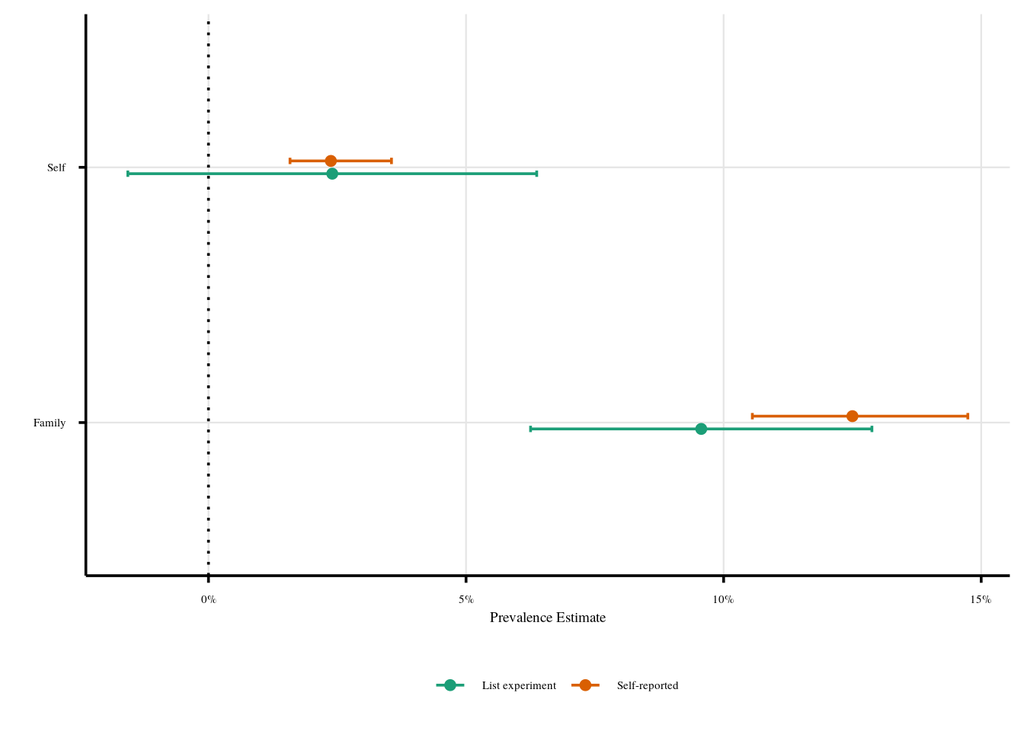

```r
list_exp_res |>
  ggplot(aes(x = estimate, y = name, color = type)) +
  geom_vline(xintercept = 0, lty = "dotted") +
  geom_point(position = position_dodge(width = .1)) +
  geom_errorbar(
    aes(xmin = lower, xmax = upper),
    width = .05,
    position = position_dodge(width = .1)
  ) +
  scale_x_continuous(labels = scales::label_percent(scale = 1)) +
  labs(
    x = "Prevalence Estimate",
    y = "",
    color = ""
  ) +
  theme(legend.position = "bottom") +
  scale_color_brewer(palette = "Dark2")
```

```r
#ggsave(here::here("figs/list_experiment.pdf"), width = 7, height = 5)
```

# Models

Fitting four different models:

1. Naive: Linear regression without controlling for confounding on effect modification.
2. Controlled regression: linear regression with controlling for confounding on effect modification.
3. IPW: Pooled IPW estimator.
4. Propensity score matching: nearest-neighbor propensity score matching.

Fitting the models:

## Naive

```r
naive <- lm(
  selected ~ ingroup*crsv_self_family,
  data = merged
)
```

## Controlled

```r
cont <- lm(
  selected ~ ingroup*(
    crsv_self_family +
    resp_age +
    resp_ethn_Bosniak +
    resp_ethn_Serb +
    resp_ethn_Croat +
    resp_male +
    victim_other +
    resp_educ_Bachelor +
    #resp_educ_Doctor +
    resp_educ_Master +
    resp_educ_None +
    resp_educ_PostSecondary +
    resp_educ_Primary +
    resp_educ_Secondary +
    resp_educ_Vocational
  ),
  data = merged
)
```

## Pooled IPW

```r
weighted <- lm(
  selected ~ ingroup*(
    crsv_self_family +
      resp_age +
      resp_ethn_Bosniak +
      resp_ethn_Serb +
      resp_ethn_Croat +
      resp_male +
      victim_other +
      resp_educ_Bachelor +
      #resp_educ_Doctor +
      resp_educ_Master +
      resp_educ_None +
      resp_educ_PostSecondary +
      resp_educ_Primary +
      resp_educ_Secondary +
      resp_educ_Vocational
  ),
  data = merged,
  weights = ipw
)
```

## Propensity score matching

```r
for_mod <-
  survey |>
  drop_na(crsv_self_family, resp_ethn)

matched <- MatchIt::matchit(
  crsv_self_family ~ resp_age +
    resp_ethn_Bosniak +
    resp_ethn_Croat +
    resp_ethn_Serb +
    resp_educ_Bachelor +
    resp_educ_Master +
    resp_educ_None +
    resp_educ_PostSecondary +
    resp_educ_Primary +
    resp_educ_Secondary +
    resp_educ_Vocational +
    resp_male +
    victim_other,
  method = "nearest",
  distance = for_mod$prop,
  caliper = .1,
  caliper.scale = "logit",
  data = for_mod
)
```

Checking match quality:

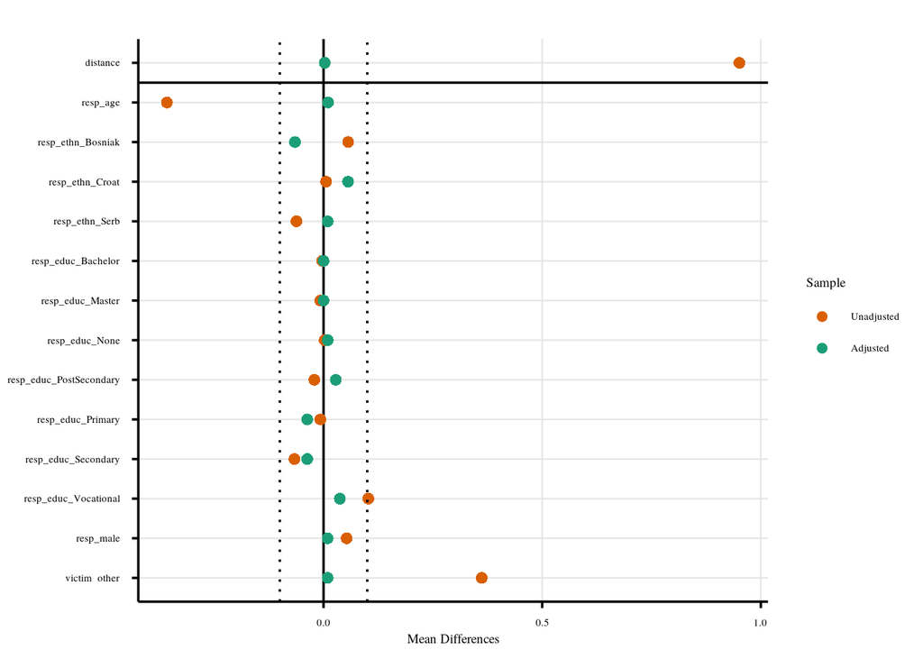

```r
cobalt::love.plot(matched) +
  theme_paper() +
  geom_vline(xintercept = c(-.1, .1), lty = "dotted") +
  labs(title = "") +
  scale_color_brewer(palette = "Dark2", direction = -1)
```

```r
#ggsave(here::here("figs/balance_psm.pdf"), width = 7, height = 5)
```

Fitting the controlled regression to the matched data. Essentially, using matching as non-parametric preprocessing, as suggested by Ho et al. 2007: we know that there is remaining imbalance, so we know that the difference in means estimator might not be consistent.

```r
matched_df <- MatchIt::match.data(matched)

# have to rejoin this into the conjoint data:
matched_rejoined <-
  conjoint |>
  left_join(matched_df, join_by(uuid)) |>
  mutate(
    outgroup = if_else(resp_ethn != ethnicity, 1, 0),
    # again, second outgroup measure: wartime enemies
    outgroup2 = if_else(
      (resp_ethn %in% c("Bosniak", "Croat") & ethnicity == "Serb") |
        (resp_ethn == "Serb" & ethnicity %in% c("Bosniak", "Croat")),
      1L,
      0L
    ),
    ingroup = 1 - outgroup,
    ingroup2 = 1 - outgroup2
  ) |>
  drop_na(resp_ethn) |>
  fastDummies::dummy_cols(
    c("ethnicity", "age", "class", "education", "sex", "resp_ethn"),
    remove_selected_columns = TRUE
  ) |>
  semi_join(matched_df, join_by(uuid))

matching <- lm(
  selected ~ ingroup*(
    crsv_self_family +
    resp_age +
    resp_ethn_Bosniak +
    resp_ethn_Serb +
    resp_ethn_Croat +
    resp_male +
    victim_other +
    resp_educ_Bachelor +
    #resp_educ_Doctor +
    resp_educ_Master +
    resp_educ_None +
    resp_educ_PostSecondary +
    resp_educ_Primary +
    resp_educ_Secondary +
    resp_educ_Vocational
  ),
  data = matched_rejoined
)
```

# Results

Setup:

```r
mods <- tribble(
  ~name, ~model,
  "Naive", naive,
  "Controlled Reg.", cont,
  "IPW", weighted,
  "Matched", matching
)

regtable <- function(models, ...) {
  modelsummary::modelsummary(
    models,
    stars = c("*" = .1, "**" = .05, "***" = .01),
    #gof_omit = "Log.Lik|BIC|F$",
    ...
  )
}

avgpreds_crsv <- function(model) {
  avg_predictions(
    model,
    variables = c("ingroup", "crsv_self_family"),
    vcov = vcovCL(model, cluster = ~uuid, type = "HC1")
  )
}

for_vis <-
  mods |>
  mutate(preds = map(model, avgpreds_crsv)) |>
  select(preds, name) |>
  unnest(preds) |>
  mutate(
    ingroup = if_else(ingroup == 0, "Outgroup", "Ingroup"),
    crsv_self_family = factor(
      if_else(crsv_self_family == 1, "CRSV", "No CRSV"),
      levels = c("CRSV", "No CRSV")
    ),
    across(c(ingroup, crsv_self_family, name), factor),
    ingroup = forcats::fct_relevel(ingroup, "Outgroup", "Ingroup"),
    name = name |> factor(
      levels = c(
        "Naive",
        "Controlled Reg.",
        "IPW",
        "Matched"
      )
    )
  )
```

Regression table; we see some attenuation when controlling (effect becomes weaker from Naive -> controlled regression -> pooled IPW), matching outlier but relies on very low number of obs (should either leave calipers alone or just drop PSM altogether?)

```r
list(
  `Naive` = naive,
  `Controlled reg.` = cont,
  `IPW` = weighted,
  `Matched` = matching
) |>
  map(\(m) coeftest(m, .vcov = vcovCL(m, cluster = ~uuid, type = "HC1"))) |>
  regtable(
    coef_map = c(
      "ingroup" = "Ingroup",
      "crsv_self_family" = "CRSV",
      "ingroup:crsv_self_family" = "Ingroup × CRSV"
    )
  )
```

|  | Naive | Controlled reg. | IPW | Matched |
| --- | --- | --- | --- | --- |
| Ingroup | 0.327*** | 0.116 | 0.092 | 0.334** |
|  | (0.010) | (0.076) | (0.075) | (0.157) |
| CRSV | 0.033* | 0.028 | 0.009 | 0.018 |
|  | (0.017) | (0.018) | (0.018) | (0.024) |
| Ingroup × CRSV | -0.111*** | -0.099*** | -0.067** | -0.105** |
|  | (0.029) | (0.030) | (0.030) | (0.042) |
| Num.Obs. | 11290 | 11290 | 11290 | 2532 |
| AIC | 37923.3 | 37855.1 | 38576.3 | 8505.0 |
| BIC | 120668.5 | 120439.1 | 121160.3 | 23143.6 |

* p < 0.1, ** p < 0.05, *** p < 0.01

Model estimates visually:

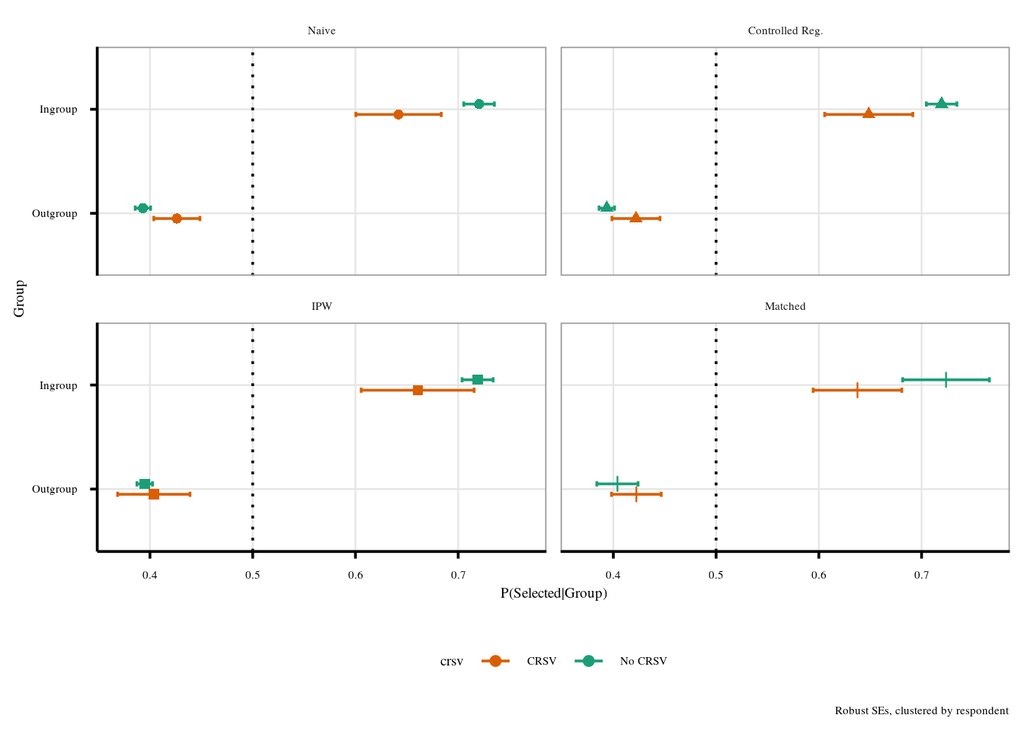

```r
for_vis |>
  ggplot(
    aes(
      x = estimate,
      y = ingroup,
      color = crsv_self_family,
      shape = name
    )
  ) +
  geom_vline(xintercept = .5, lty = "dotted") +
  geom_point(position = position_dodge(width = 0.2)) +
  geom_errorbar(
    aes(xmin = conf.low, xmax = conf.high),
    width = 0.1,
    position = position_dodge(width = 0.2)
  ) +
  guides(shape = "none") +
  labs(
    x = "P(Selected|Group)",
    y = "Group",
    color = "crsv",
    caption = "Robust SEs, clustered by respondent"
  ) +
  facet_wrap(~name, ncol = 2) +
  theme(
    panel.border = element_rect(
      colour = "grey60",
      fill = NA,
      linewidth = 0.6
    ),
    legend.position = "bottom"
  ) +
  scale_color_brewer(palette = "Dark2", direction = -1)
```

```r
#ggsave(here::here("figs/crsv_estimates.pdf"), width = 7, height = 5)
```

As interaction plots:

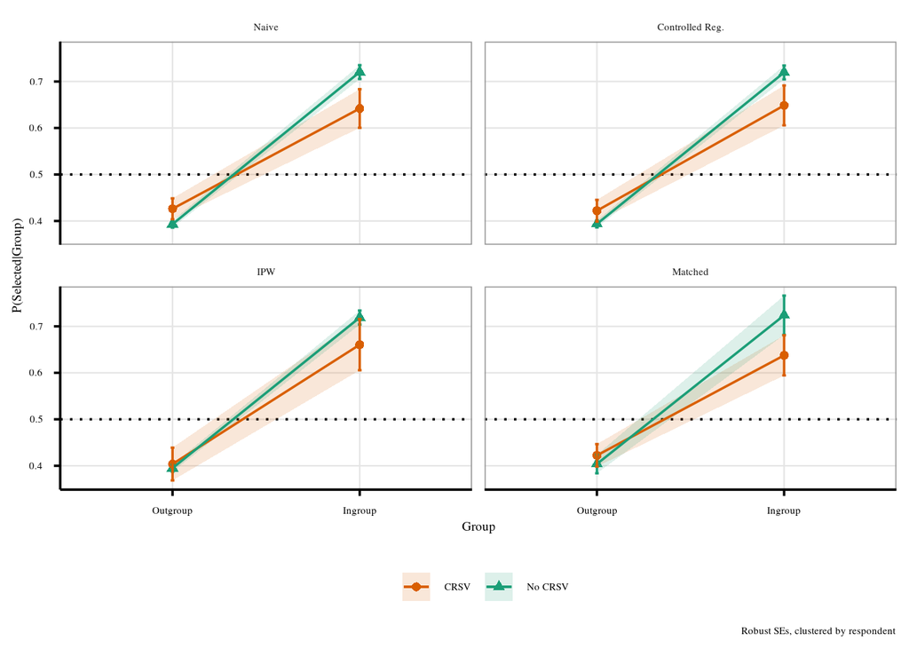

```r
for_vis |>
  ggplot(
    aes(
      x = ingroup,
      y = estimate,
      color = crsv_self_family,
      shape = crsv_self_family
    )
  ) +
  geom_hline(yintercept = .5, lty = "dotted") +
  geom_ribbon(
    aes(
      ymin = conf.low,
      ymax = conf.high,
      group = crsv_self_family,
      fill = crsv_self_family
    ),
    alpha = .15,
    color = NA
  ) +
  geom_point() +
  geom_line(aes(group = crsv_self_family)) +
  geom_errorbar(
    aes(ymin = conf.low, ymax = conf.high),
    width = 0.02
  ) +
  labs(
    y = "P(Selected|Group)",
    x = "Group",
    color = "",
    fill = "",
    shape = "",
    caption = "Robust SEs, clustered by respondent"
  ) +
  facet_wrap(~name, ncol = 2) +
  theme(
    panel.border = element_rect(
      colour = "grey60",
      fill = NA,
      linewidth = 0.6
    ),
    legend.position = "bottom"
  ) +
  scale_color_brewer(palette = "Dark2", direction = -1) +
  scale_fill_brewer(palette = "Dark2", direction = -1)
```

```r
#ggsave(here::here("figs/crsv_interaction_plots.pdf"), width = 7, height = 5)
```

Full AMCEs/MMs:

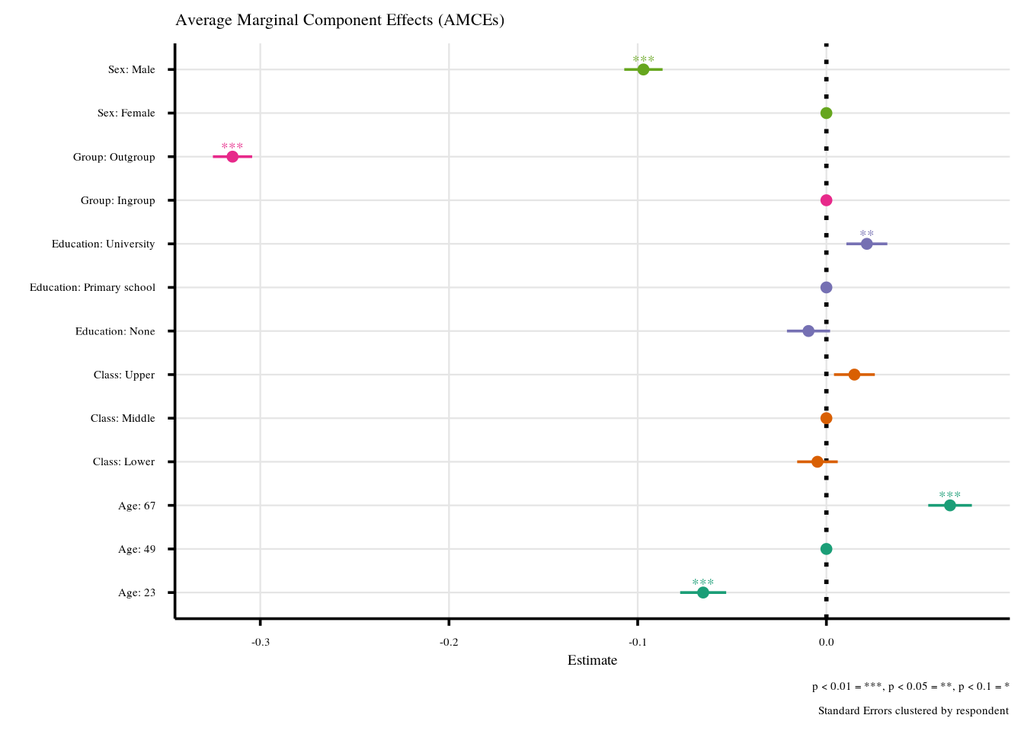

```r
new <-
  conjoint |>
  left_join(survey, join_by(uuid)) |>
  mutate(
    across(where(is.character), factor),
    group = if_else(resp_ethn == ethnicity, "Ingroup", "Outgroup"),
    # baselines festlegen (erstes factor-level wird von `lm` als baseline verwendet;
    # relevant für AMCEs: erwarteter change in P(selected) bei Wechsel von
    # Referenzkategorie/-merkmal zu gg. Kategorie:
    ethnicity = factor(
      ethnicity, levels = c("Bosniak", "Croat", "Serb")
    ),
    sex = factor(sex, levels = c("Female", "Male")),
    class = factor(
      class,
      levels = c(
        "Middle",
        "Lower",
        "Upper"
      )
    ),
    education = factor(
      education,
      levels = c(
        "Primary school",
        "None",
        "University"
      )
    ),
    age = factor(age, levels = c("49", "23", "67")),
    group = factor(group, levels = c("Ingroup", "Outgroup"))
  ) |>
  drop_na(resp_ethn)

amce_mod <- lm(selected ~ group + age + class + education + sex, data = new)

amce_clean <-
  amce_mod |>
  coeftest(vcov. = vcovCL(amce_mod, cluster = ~uuid, type = "HC1")) |>
  broom::tidy() |>
  mutate(
    lower = estimate - std.error,
    upper = estimate + std.error,
    signif = case_when(
      p.value < 0.01 ~ "***",
      p.value < 0.05 ~ "**",
      p.value < 0.1 ~ "*",
      TRUE ~ ""
    )
  ) |>
  filter(term != "(Intercept)") |>
  # baseline levels wieder mit rein (alles auf null)
  bind_rows(
    tribble(
      ~term, ~estimate, ~lower, ~upper,
      "groupIngroup", 0, 0, 0,
      "sexFemale", 0, 0, 0,
      "classMiddle", 0, 0, 0,
      "educationPrimary school", 0, 0, 0,
      "age49", 0, 0, 0
    )
  ) |>
  mutate(
    feature = stringr::str_to_title(stringr::str_extract(term, "^[a-zä]+")),
    attr = gsub("^[a-zä]+", "", term),
    name = paste0(feature, ": ", attr)
  )

amce_clean |>
  ggplot(aes(x = estimate, y = name, color = feature)) +
  geom_vline(xintercept = 0, lty = "dotted", linewidth = 1) +
  geom_point() +
  geom_text(aes(label = signif), position = position_nudge(y = .2)) +
  geom_linerange(aes(xmin = lower, xmax = upper)) +
  theme(legend.position = "none") +
  labs(
    title = "Average Marginal Component Effects (AMCEs)",
    x = "Estimate",
    y = "",
    caption = "p < 0.01 = ***, p < 0.05 = **, p < 0.1 = *\nStandard Errors clustered by respondent"
  ) +
  scale_color_brewer(palette = "Dark2")
```

```r
#ggsave(here::here("figs/amces_full.pdf"), width = 7, height = 5)
```

Marginal means:

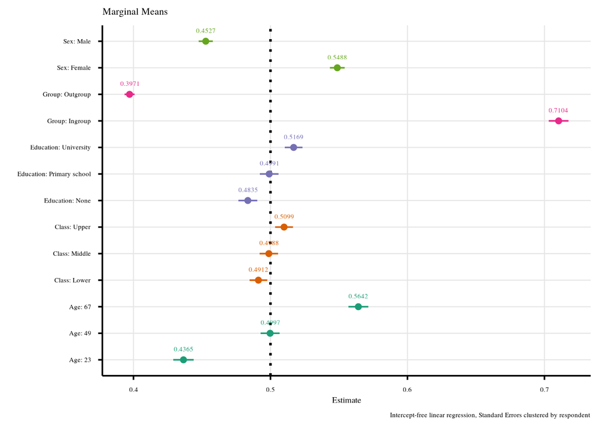

```r
intercept_free_mods <- list(
  lm(selected ~ 0 + group, data = new),
  lm(selected ~ 0 + sex, data = new),
  lm(selected ~ 0 + education, data = new),
  lm(selected ~ 0 + class, data = new),
  lm(selected ~ 0 + age, data = new)
)

intercept_free_mods |>
  map(function(model) {
    model |>
      coeftest(vcov. = vcovCL(model, cluster = ~uuid, type = "HC1")) |>
      broom::tidy()
  }) |>
  bind_rows() |>
  mutate(
    lower = estimate - std.error,
    upper = estimate + std.error,
    feature = stringr::str_extract(term, "^[a-zä]+"),
    attr = gsub("^[a-zä]+", "", term),
    name = paste0(stringr::str_to_title(feature), ": ", attr),
    lab = as.character(round(estimate, 4))
  ) |>
  select(feature, attr, name, estimate, std.error, lower, upper, lab) |>
  ggplot(aes(x = estimate, y = name, color = feature)) +
  geom_vline(xintercept = .5, lty = "dotted", linewidth = 1) +
  geom_point() +
  geom_text(aes(label = lab), position = position_nudge(y = .4), size = 4) +
  geom_linerange(aes(xmin = lower, xmax = upper)) +
  theme(legend.position = "none") +
  labs(
    title = "Marginal Means",
    caption = "Intercept-free linear regression, Standard Errors clustered by respondent",
    x = "Estimate",
    y = ""
  ) +
  scale_color_brewer(palette = "Dark2")
```

```r
#ggsave(here::here("figs/marginal_means_full.pdf"), width = 7, height = 5)
```

Do the two scenarios differ?

```r
restr_scenarios <-
  new |>
  select(age:sex, group, selected, scenario) |>
  lm(selected ~ ., data = _)

unrestr_scenarios <-
  new |>
  select(age:sex, group, selected, scenario) |>
  lm(selected ~ scenario*(.), data = _)

anova(restr_scenarios, unrestr_scenarios, test = "F")
```

```
Analysis of Variance Table

Model 1: selected ~ age + class + education + sex + group + scenario
Model 2: selected ~ scenario * (age + class + education + sex + group +
    scenario)
  Res.Df    RSS Df Sum of Sq      F Pr(>F)
1  11280 2516.8
2  11272 2514.8  8    1.9748 1.1065 0.3551
```

And for ingroup specifically?

```r
anova(
  lm(selected ~ group, data = new),
  lm(selected ~ group*scenario, data = new)
)
```

```
Analysis of Variance Table

Model 1: selected ~ group
Model 2: selected ~ group * scenario
  Res.Df    RSS Df Sum of Sq      F Pr(>F)
1  11288 2578.2
2  11286 2578.1  2  0.034888 0.0764 0.9265
```